# 02 - Customizing Seaborn Plots

Seaborn offers several convenience functions for working with palettes. The palplot() function display color swatches in a Jupyter notebook. In order to retrieve the current palette, you can use the color palette function. This short example shows the exact colors included in the default palettes and how to use each of these functions.

```python
reticulate::repl_python()
```

```
Python 3.6.11 (/home/cla/.local/share/r-miniconda/envs/r-reticulate/bin/python)
Reticulate 1.18 REPL -- A Python interpreter in R.
```

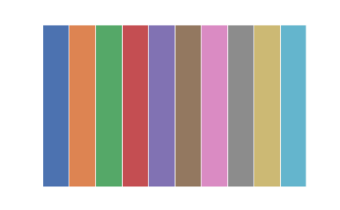

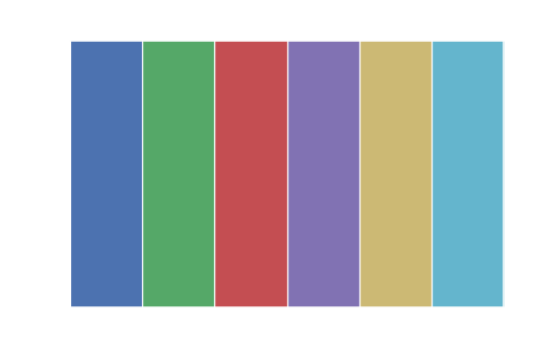

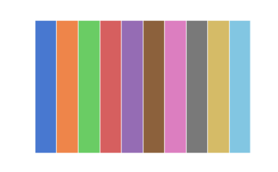

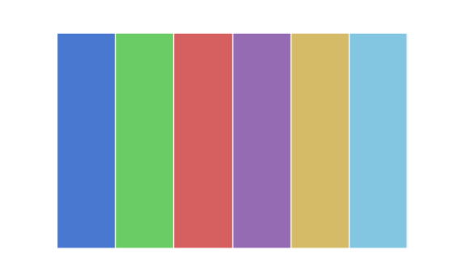

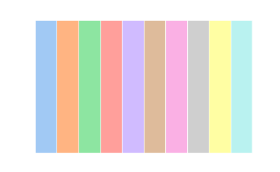

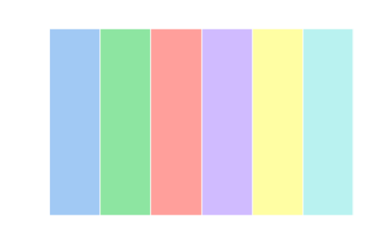

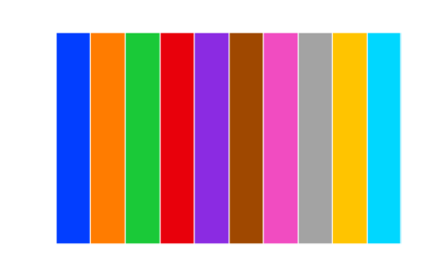

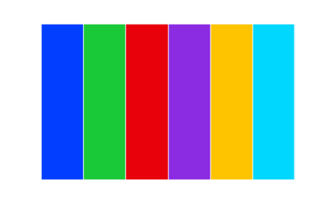

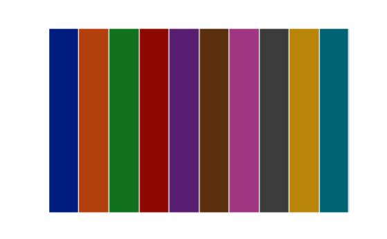

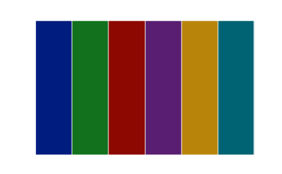

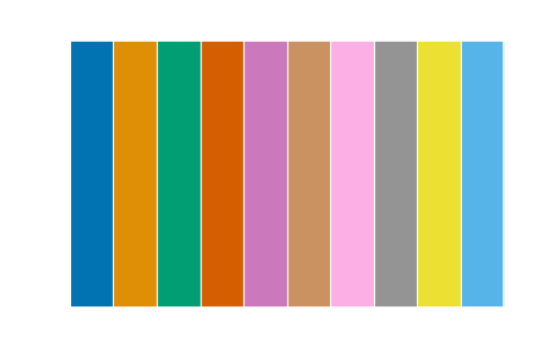

```
SystemExit: None
```

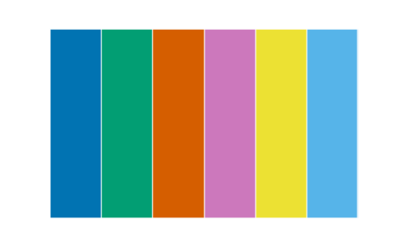

```python
for p in sns.palettes.SEABORN_PALETTES:
  sns.set_palette(p)
  sns.palplot(sns.color_palette())
  plt.show()
quit()
```

**5. Defining Custom Palettes**

There are three main types of color palettes. Circular color palettes are used for categorical data that is not ordered. Sequential palettes are useful when the data has a consistent range from high to low values. A diverging color palette is best used when both the high and the low values are interesting. Seaborn allows us to create each of these types of palettes in multiple manners. Each example on this slide shows a different automatically created palette of 12 different colors.

```python
reticulate::repl_python()
```

```
Python 3.6.11 (/home/cla/.local/share/r-miniconda/envs/r-reticulate/bin/python)
Reticulate 1.18 REPL -- A Python interpreter in R.
```

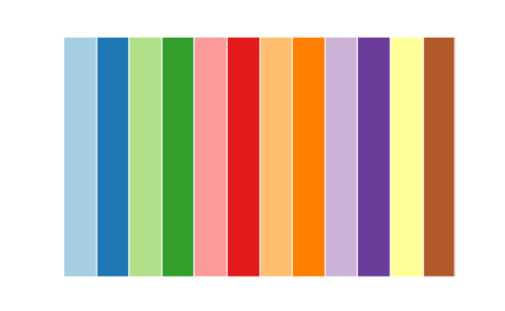

```python
sns.palplot(sns.color_palette('Paired', 12))
plt.show()
```

```python
reticulate::repl_python()
```

```
Python 3.6.11 (/home/cla/.local/share/r-miniconda/envs/r-reticulate/bin/python)
Reticulate 1.18 REPL -- A Python interpreter in R.
```

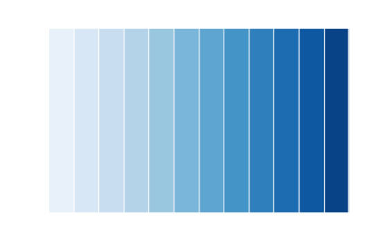

```python
# Sequential colors: when data has a consistent range from low to high
sns.palplot(sns.color_palette('Blues', 12))
plt.show()
```

```python
reticulate::repl_python()
```

```
Python 3.6.11 (/home/cla/.local/share/r-miniconda/envs/r-reticulate/bin/python)
Reticulate 1.18 REPL -- A Python interpreter in R.
```

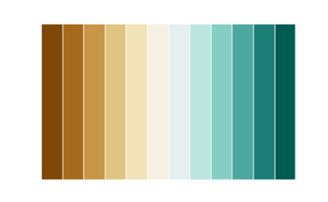

```python
# Diverging colors: when both the low and high values are interesting
sns.palplot(sns.color_palette('BrBG', 12))
plt.show()
```

**6. Let’s practice!**

Now that we have walked through creating and using some palettes in Seaborn, we can now apply these concepts to some more examples.

### **Matplotlib color codes**

Seaborn offers several options for modifying the colors of your visualizations. The simplest approach is to explicitly state the color of the plot. A quick way to change colors is to use the standard `matplotlib` color codes.

**Instructions**

- Set the default Seaborn style and enable the `matplotlib` color codes.
- Create a `distplot` for the `fmr_3` column using `matplotlib`’s magenta (`m`) color code.

```python
reticulate::repl_python()
```

```
Python 3.6.11 (/home/cla/.local/share/r-miniconda/envs/r-reticulate/bin/python)
Reticulate 1.18 REPL -- A Python interpreter in R.
```

```python
fig, ax = plt.subplots()
_ = fig.tight_layout(pad = 5)
```

[output not shown]

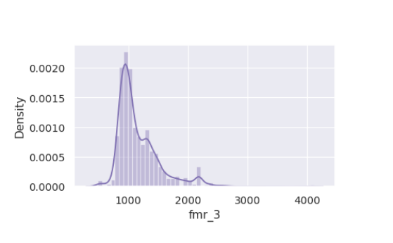

```python
# Set style, enable color code, and create a magenta distplot
_ = sns.set(color_codes = True)
_ = sns.distplot(df['fmr_3'], color = 'm')
# Show the plot
plt.show()
```

```python
plt.clf()
```

This is a quick way to modify the colors of a plot.

### **Using default palettes**

Seaborn includes several default palettes that can be easily applied to your plots. In this example, we will look at the impact of two different palettes on the same `distplot`.

**Instructions**

- Create a `for` loop to show the difference between the `bright` and `colorblind` palette.
- Set the palette using the `set_palette()` function.
- Use a `distplot` of the `fmr_3` column.

```python
reticulate::repl_python()
```

```
Python 3.6.11 (/home/cla/.local/share/r-miniconda/envs/r-reticulate/bin/python)
Reticulate 1.18 REPL -- A Python interpreter in R.
```

```python
fig, ax = plt.subplots()
_ = fig.tight_layout(pad = 5)
```

[output not shown]

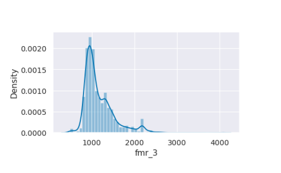

```python
# Loop through differences between bright and colorblind palettes
for p in ['bright', 'colorblind']:
    _ = sns.set_palette(p)
    _ = sns.distplot(df['fmr_3'])
    plt.show()
```

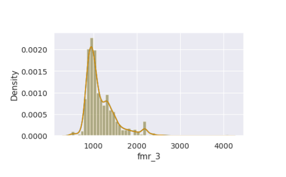

```python
    # Clear the plots
```

```python
    plt.clf()
```

Using the default color blind palette is a good option for making sure your visualizations are easy to read for individuals with degrees of color blindness.

### **Color Palettes**

When visualizing multiple elements of data that do not have inherent ordering. Which type of Seaborn palette should you use?

**Possible Answers**

1. sequential
2. circular
3. diverging
4. None of the above.

Answer: 2

### **Creating Custom Palettes**

Choosing a cohesive palette that works for your data can be time consuming. Fortunately, Seaborn provides the `color_palette()` function to create your own custom sequential, categorical, or diverging palettes. Seaborn also makes it easy to view your palettes by using the `palplot()` function.

In this exercise, you can experiment with creating different palettes.

**Instructions**

1. Create and display a `Purples` sequential palette containing 8 colors.
2. Create and display a palette with 10 colors using the `husl` system.
3. Create and display a diverging palette with 6 colors `coolwarm`.

```python
reticulate::repl_python()
```

```
Python 3.6.11 (/home/cla/.local/share/r-miniconda/envs/r-reticulate/bin/python)
Reticulate 1.18 REPL -- A Python interpreter in R.
```

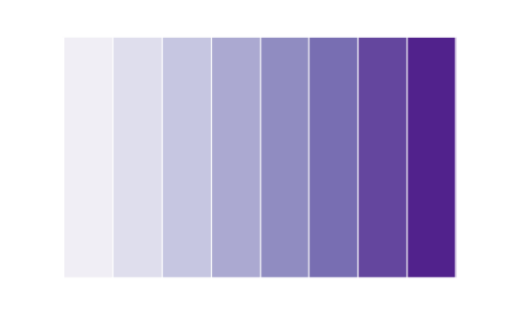

```python
sns.palplot(sns.color_palette('Purples', 8))
plt.show()
```

```python
reticulate::repl_python()
```

```
Python 3.6.11 (/home/cla/.local/share/r-miniconda/envs/r-reticulate/bin/python)
Reticulate 1.18 REPL -- A Python interpreter in R.
```

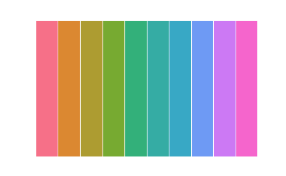

```python
sns.palplot(sns.color_palette('husl', 10))
plt.show()
```

```python
reticulate::repl_python()
```

```
Python 3.6.11 (/home/cla/.local/share/r-miniconda/envs/r-reticulate/bin/python)
Reticulate 1.18 REPL -- A Python interpreter in R.
```

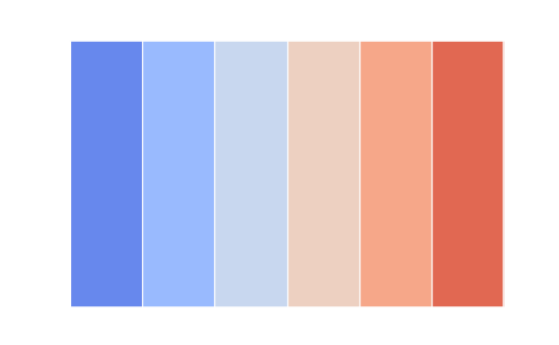

```python
sns.palplot(sns.color_palette('coolwarm', 6))
plt.show()
```

Color palette possibilities are limitless. Using these helper functions will allow you to create unique and visually appealing plots that will stand out and get your points across.

## **Customizing with Matplotlib**

**1. Customizing with matplotlib**

Seaborn has several convenience functions for modifying components of your final Seaborn visualization. Since Seaborn is based on matplotlib, there is a wide variety of options for further modifying your Seaborn plots. This video will show you how to further configure your plots using the underlying matplotlib library.

**2. Matplotlib Axes**

As we have discussed in prior lessons, Seaborn does its best to make plots look good with minimal changes on your part. By using matplotlib’s axes objects, you can customize almost any element of your plot. The most important concept is to add additional code to create the subplots using matplotlib’s subplots functions and pass the resulting axes object to the Seaborn function. Seaborn will then plot the data on the given axes. In this example, I have used the ax set function to customize the x-label to show that the tuition data is for the 2013-2014 school year.

```python
reticulate::repl_python()
```

```
Python 3.6.11 (/home/cla/.local/share/r-miniconda/envs/r-reticulate/bin/python)
Reticulate 1.18 REPL -- A Python interpreter in R.
```

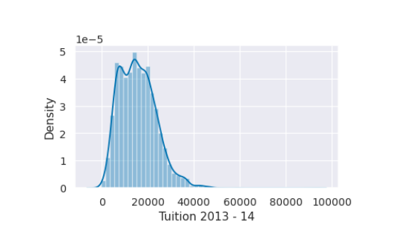

```python
fig, ax = plt.subplots()
_ = fig.tight_layout(pad = 5)
sns.distplot(df2['Tuition'], ax = ax)
_ = ax.set(xlabel = 'Tuition 2013 - 14')
plt.show()
```

```python
plt.clf()
```

**3. Further Customizations**

This example shows how much control you have once you start modifying the axes. In addition to setting an x-label, I have also changed the y-label and set a limit so that tuition ranges are only between 0 and $50,000. Finally, I added a title.

```python
reticulate::repl_python()
```

```
Python 3.6.11 (/home/cla/.local/share/r-miniconda/envs/r-reticulate/bin/python)
Reticulate 1.18 REPL -- A Python interpreter in R.
```

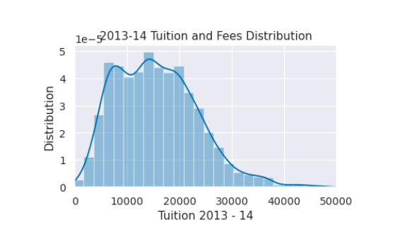

```python
fig, ax = plt.subplots()
_ = fig.tight_layout(pad = 5)
sns.distplot(df2['Tuition'], ax = ax)
_ = ax.set(xlabel = 'Tuition 2013 - 14',
           ylabel = 'Distribution',
           xlim = (0, 50000),
           title = '2013-14 Tuition and Fees Distribution')
plt.show()
```

```python
plt.clf()
```

**4. Combining Plots**

```python
reticulate::repl_python()
```

```
Python 3.6.11 (/home/cla/.local/share/r-miniconda/envs/r-reticulate/bin/python)
Reticulate 1.18 REPL -- A Python interpreter in R.
```

```python
fig, (ax0, ax1) = plt.subplots(nrows = 1, ncols = 2, sharey = True, figsize = (7, 4))
_ = fig.tight_layout(pad = 5)

_ = sns.distplot(df2['Tuition'], ax = ax0)
_ = sns.distplot(df2.query('Regions == "South East"')['Tuition'], ax = ax1)
_ = ax1.set(xlabel = 'Tuition (MN)', xlim = (0, 70000))
_ = ax1.axvline(x = 20000, label = 'My Budget', linestyle = '--')
_ = ax1.legend()
```

**5. Combining Plots**

This example shows how much control you can have when creating your own visualizations.

```python
reticulate::repl_python()
```

```
Python 3.6.11 (/home/cla/.local/share/r-miniconda/envs/r-reticulate/bin/python)
Reticulate 1.18 REPL -- A Python interpreter in R.
```

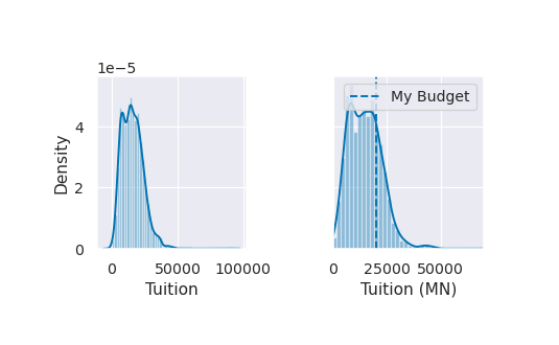

```python
plt.show()
```

```python
plt.clf()
```

**6. Let’s practice!**

Now that you understand the basics of customizing your Seaborn plots using matplotlib, we can try some exercises to get some real world experience.

### **Using matplotlib axes**

Seaborn uses `matplotlib` as the underlying library for creating plots. Most of the time, you can use the Seaborn API to modify your visualizations but sometimes it is helpful to use `matplotlib`’s functions to customize your plots. The most important object in this case is `matplotlib`’s `axes`.

Once you have an `axes` object, you can perform a lot of customization of your plot.

In these examples, the US HUD data is loaded in the dataframe `df` and all libraries are imported.

**Instructions**

- Use `plt.subplots()` to create a `axes` and `figure` objects.
- Plot a `distplot` of column `fmr_3` on the `axes`.
- Set a more useful label on the x axis of “3 Bedroom Fair Market Rent”.

```python
reticulate::repl_python()
```

```
Python 3.6.11 (/home/cla/.local/share/r-miniconda/envs/r-reticulate/bin/python)
Reticulate 1.18 REPL -- A Python interpreter in R.
```

```python
# Create a figure and axes
fig, ax = plt.subplots()
_ = fig.tight_layout(pad = 5)

# Plot the distribution of data
_ = sns.distplot(df['fmr_3'], ax = ax)
# Create a more descriptive x axis label
ax.set(xlabel = "3 Bedroom Fair Market Rent")
```

```
[Text(0.5, 19.049999999999997, '3 Bedroom Fair Market Rent')]
```

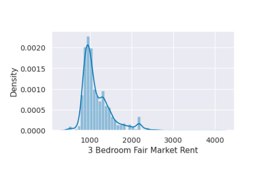

```python
# Show the plot
plt.show()
```

```python
plt.clf()
```

Now you know the basics of how to customize a plot.

### **Additional plot customizations**

The `matplotlib` API supports many common customizations such as labeling axes, adding titles, and setting limits. Let’s complete another customization exercise.

**Instructions**

- Create a `distplot` of the `fmr_1` column.
- Modify the x axis label to say “1 Bedroom Fair Market Rent”.
- Change the x axis limits to be between 100 and 1500.
- Add a descriptive title of “US Rent” to the plot.

```python
reticulate::repl_python()
```

```
Python 3.6.11 (/home/cla/.local/share/r-miniconda/envs/r-reticulate/bin/python)
Reticulate 1.18 REPL -- A Python interpreter in R.
```

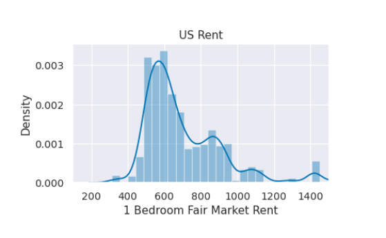

```python
# Create a figure and axes
fig, ax = plt.subplots()
_ = fig.tight_layout(pad = 5)

# Plot the distribution of 1 bedroom rents
_ = sns.distplot(df['fmr_1'], ax = ax)
# Modify the properties of the plot
_ = ax.set(xlabel="1 Bedroom Fair Market Rent",
       xlim=(100, 1500),
       title = "US Rent")

# Display the plot
plt.show()
```

```python
plt.clf()
```

Making these types of customizations to your plots can really improve their impact.

### **Adding annotations**

Each of the enhancements we have covered can be combined together. In the next exercise, we can annotate our distribution plot to include lines that show the mean and median rent prices.

For this example, the palette has been changed to `bright` using `sns.set_palette()`

**Instructions**

- Create a `figure` and `axes`.
- Plot the `fmr_1` column distribution.
- Add a vertical line using `axvline` for the `median` and `mean` of the values which are already defined.

```python
reticulate::repl_python()
```

```
Python 3.6.11 (/home/cla/.local/share/r-miniconda/envs/r-reticulate/bin/python)
Reticulate 1.18 REPL -- A Python interpreter in R.
```

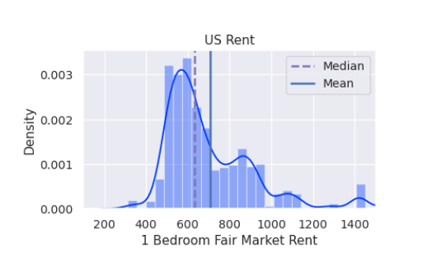

```python
_ = sns.set_palette('bright')

# Create a figure and axes. Then plot the data
fig, ax = plt.subplots()
_ = fig.tight_layout(pad = 5)
_ = sns.distplot(df['fmr_1'], ax = ax)
# Customize the labels and limits
_ = ax.set(xlabel = "1 Bedroom Fair Market Rent", xlim = (100,1500), title = "US Rent")

# Add vertical lines for the median and mean
_ = ax.axvline(x = median, color = 'm', label = 'Median', linestyle = '--', linewidth = 2)
_ = ax.axvline(x = mean, color = 'b', label = 'Mean', linestyle = '-', linewidth = 2)

# Show the legend and plot the data
_ = ax.legend()
plt.show()
```

```python
plt.clf()
```

That was a long example but should show the power available to you!

### **Multiple plots**

For the final exercise we will plot a comparison of the fair market rents for 1-bedroom and 2-bedroom apartments.

**Instructions**

- Create two axes objects, `ax0` and `ax1`.
- Plot `fmr_1` on `ax0` and `fmr_2` on `ax1`.
- Display the plots side by side.

```python
reticulate::repl_python()
```

```
Python 3.6.11 (/home/cla/.local/share/r-miniconda/envs/r-reticulate/bin/python)
Reticulate 1.18 REPL -- A Python interpreter in R.
```

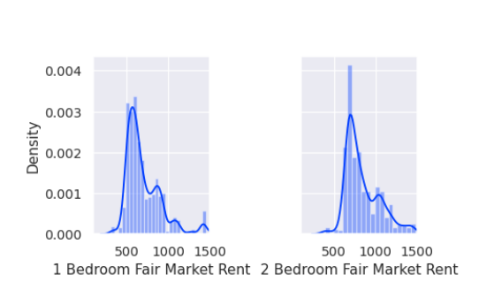

```python
# Create a plot with 1 row and 2 columns that share the y axis label
fig, (ax0, ax1) = plt.subplots(nrows = 1, ncols = 2, sharey = True)
_ = fig.tight_layout(pad = 5)

# Plot the distribution of 1 bedroom apartments on ax0
_ = sns.distplot(df['fmr_1'], ax = ax0)
_ = ax0.set(xlabel = "1 Bedroom Fair Market Rent", xlim = (100,1500))

# Plot the distribution of 2 bedroom apartments on ax1
_ = sns.distplot(df['fmr_2'], ax = ax1)
_ = ax1.set(xlabel = "2 Bedroom Fair Market Rent", xlim = (100,1500))

# Display the plot
plt.show()
```

```python
plt.clf()
```

Well done. You have completed the customization section of the course.